# Equal Pay Analysis

2020-10-13

# Omega Group plc- Pay Discrimination

At the last board meeting of Omega Group Plc., the headquarters of a large multinational company, the issue was raised that women were being discriminated in the company, in the sense that the salaries were not the same for male and female executives. A quick analysis of a sample of 50 employees (of which 24 men and 26 women) revealed that the average salary for men was about 8,700 higher than for women. This seemed like a considerable difference, so it was decided that a further analysis of the company salaries was warranted.

## Loading the data

```r
omega <- read_csv(here::here("data", "omega.csv"))
glimpse(omega) # examine the data frame
```

```
## Rows: 50
## Columns: 3
## $ salary     <dbl> 81894, 69517, 68589, 74881, 65598, 76840, 78800, 70033, 63…
## $ gender     <chr> "male", "male", "male", "male", "male", "male", "male", "m…
## $ experience <dbl> 16, 25, 15, 33, 16, 19, 32, 34, 1, 44, 7, 14, 33, 19, 24, …
```

## Relationship Salary - Gender ?

Calculation of Summary Statistics on salary by gender (mean, SD, sample size, the t-critical, the SE, the margin of error, and the low/high endpoints of a 95% condifence interval)

```r
mosaic::favstats (salary ~ gender, data=omega)
```

```
##   gender   min    Q1 median    Q3   max  mean   sd  n missing
## 1 female 47033 60338  64618 70033 78800 64543 7567 26       0
## 2   male 54768 68331  74675 78568 84576 73239 7463 24       0
```

```r
#assign name to dataframe

salary_stats<- omega %>%

#group data by gender

group_by(gender) %>%

#calculate statistics

summarise(mean_salary=mean(salary),

          Standard_Deviation=sd(salary),

          Sample_Size=n(),

          t_criticial=qt(0.05/2,Sample_Size-1),

          Standard_Error=(Standard_Deviation/sqrt(Sample_Size)),

          margin_of_error=Standard_Error*t_criticial,

          CI_high=mean_salary+margin_of_error,

          CI_low=mean_salary-margin_of_error)

salary_stats
```

```
## # A tibble: 2 x 9
##   gender mean_salary Standard_Deviat… Sample_Size t_criticial Standard_Error
##   <chr>        <dbl>            <dbl>       <int>       <dbl>          <dbl>
## 1 female      64543.            7567.          26       -2.06          1484.
## 2 male        73239.            7463.          24       -2.07          1523.
## # … with 3 more variables: margin_of_error <dbl>, CI_high <dbl>, CI_low <dbl>
```

Let’s visualise these values

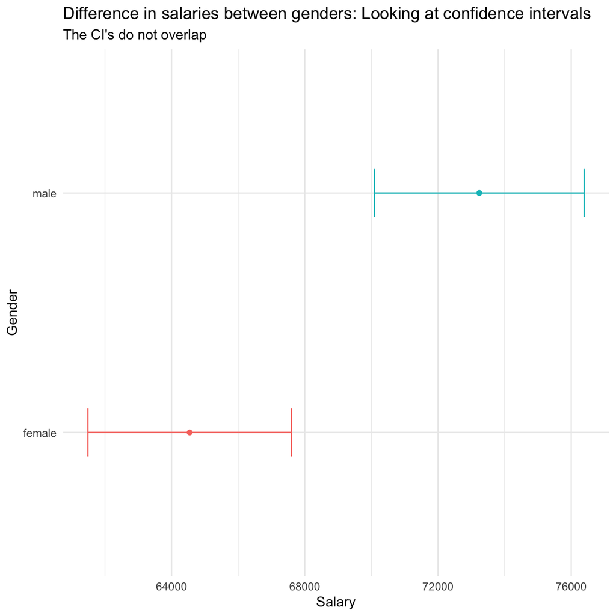

```r
ggplot(salary_stats,

       aes(x=reorder(gender, mean_salary),
           y=mean_salary,
           colour=gender)) +

  geom_point() +

  geom_errorbar(width=.2, aes(ymin=CI_low, ymax=CI_high)) +

  labs(x="Gender",
       y= "Salary",
       title= "Difference in salaries between genders: Looking at confidence intervals",
       subtitle = "The CI's do not overlap")+

  theme_minimal()+

  coord_flip()+

  theme(legend.position = "none")+

  NULL
```

Conclusion

The confidence Intervals do not overlap. Thus with 95% confidence we can conclude that there is a difference in population means between male and females salaries.

Another way of determining whether the difference in salaries is significant is to test the null hypothesis=

Mean difference in salaries is zero.

We can test this using 1) t.test() and 2) the simulation method from the infer package

1. hypothesis testing using t.test()

```r
# first we have to check whether the populations have an equal or unequal variance using the Barlett test

salary_variance <- bartlett.test(salary ~ gender,
        data = omega)

salary_variance
```

```
##
##  Bartlett test of homogeneity of variances
##
## data:  salary by gender
## Bartlett's K-squared = 0.005, df = 1, p-value = 0.9
```

```r
# Since the p-value is higher than 0.05, we can assume that they have equal variances.

# use t.test for equal variances
t_test <- t.test(salary~gender,
                 data = omega,
                 var.equal = TRUE)

t_test
```

```
##
##  Two Sample t-test
##
## data:  salary by gender
## t = -4, df = 48, p-value = 2e-04
## alternative hypothesis: true difference in means is not equal to 0
## 95 percent confidence interval:
##  -12975  -4418
## sample estimates:
## mean in group female   mean in group male
##                64543                73239
```

```r
t_test_tidy <- tidy(t_test) %>%

  # Calculate difference in means, since t.test() doesn't actually do that

  mutate(estimate = estimate1 - estimate2) %>%

  # Rearrange columns

  select(starts_with("estimate"), everything())

t_test_tidy
```

```
## # A tibble: 1 x 10
##   estimate estimate1 estimate2 statistic p.value parameter conf.low conf.high
##      <dbl>     <dbl>     <dbl>     <dbl>   <dbl>     <dbl>    <dbl>     <dbl>
## 1   -8696.    64543.    73239.     -4.09 1.65e-4        48  -12975.    -4418.
## # … with 2 more variables: method <chr>, alternative <chr>
```

2. Hypothesis testing using infer package

```r
null_distribution <- omega %>%

# specify response variable and explanatory variable
  specify(salary~gender) %>%

# hypothesize H0 (use independence because we have two samples)

  hypothesize(null="independence") %>%

# generate replicates

  generate(reps=1000, type="permute") %>%

# calculate summary statistics

  calculate(stat = "diff in means", order = c("male","female"))

null_distribution
```

```
## # A tibble: 1,000 x 2
##    replicate    stat
##        <int>   <dbl>
##  1         1  2176.
##  2         2   -47.6
##  3         3 -1527.
##  4         4 -1502.
##  5         5  -188.
##  6         6  1556.
##  7         7 -1502.
##  8         8   225.
##  9         9 -2296.
## 10        10  3052.
## # … with 990 more rows
```

```r
# visualize the p-value

obs_diff_means <- omega %>%
  specify(salary~gender) %>%
  calculate(stat = "diff in means", order = c("male","female"))

actual_difference <- obs_diff_means  %>% pull()

obs_diff_means
```

```
## # A tibble: 1 x 1
##    stat
##   <dbl>
## 1 8696.
```

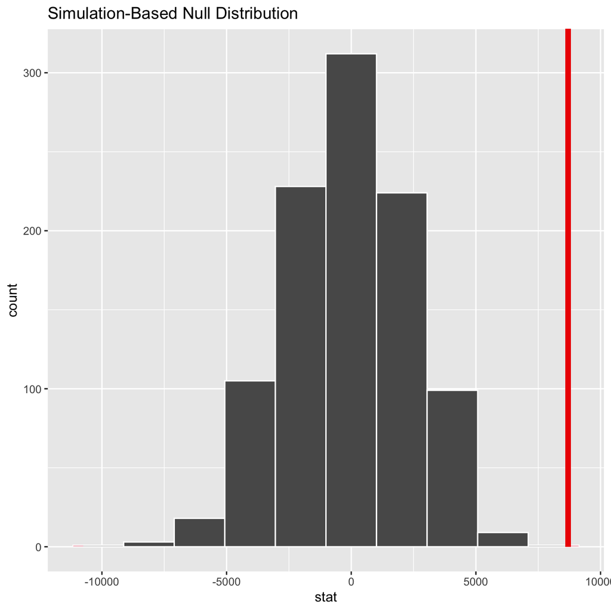

```r
  visualize(null_distribution, bins =10)+

  shade_p_value(obs_stat =obs_diff_means, direction = "both")
```

```r
obs_diff_means %>%
  get_p_value(obs_stat = 8696,direction = "both")
```

```
## # A tibble: 1 x 1
##   p_value
##     <dbl>
## 1       0
```

Conclusion:

Both methods show us that with 95% confidence we can say that there is a statistically significant difference in salaries between men and women.

- the t.test method shows a p value < 0.05 (the difference in means we observed is highly surprising in a world where h0 holds true) a t value whose absolute value is higher than 2, and the confidence interval does not include 0
- the infer method shows that the probability of an observed difference in means of about 8697 is very unlikely where H0=there is no difference in means between genders holds true with p value = 0

## Relationship Experience - Gender?

At the board meeting, someone raised the issue that there was indeed a substantial difference between male and female salaries, but that this was attributable to other reasons such as differences in experience. A questionnaire send out to the 50 executives in the sample reveals that the average experience of the men is approximately 21 years, whereas the women only have about 7 years experience on average (see table below).

```r
# Summary Statistics of salary by gender
favstats (experience ~ gender, data=omega)
```

```
##   gender min    Q1 median   Q3 max  mean    sd  n missing
## 1 female   0  0.25    3.0 14.0  29  7.38  8.51 26       0
## 2   male   1 15.75   19.5 31.2  44 21.12 10.92 24       0
```

First let’s have a look at the data

```r
# assign name to dataframe

experience_stats<- omega %>%

# group data by gender

group_by(gender) %>%

# calculate statistics

summarise(mean_experience=mean(experience),

          Standard_Deviation=sd(experience),

          Sample_Size=n(),

          t_criticial=qt(0.05/2,Sample_Size-1),

          Standard_Error=(Standard_Deviation/sqrt(Sample_Size)),

          margin_of_error=Standard_Error*t_criticial,

          CI_high=mean_experience+margin_of_error,

          CI_low=mean_experience-margin_of_error)

experience_stats
```

```
## # A tibble: 2 x 9
##   gender mean_experience Standard_Deviat… Sample_Size t_criticial Standard_Error
##   <chr>            <dbl>            <dbl>       <int>       <dbl>          <dbl>
## 1 female            7.38             8.51          26       -2.06           1.67
## 2 male             21.1             10.9           24       -2.07           2.23
## # … with 3 more variables: margin_of_error <dbl>, CI_high <dbl>, CI_low <dbl>
```

Let’s visualise this

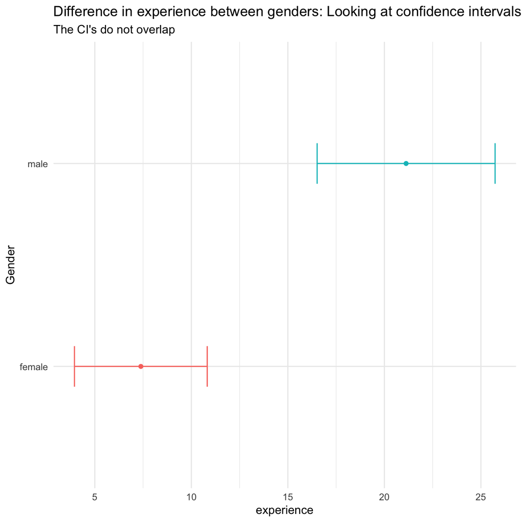

```r
ggplot(experience_stats,
       aes(x=reorder(gender, mean_experience),
           y=mean_experience,
           colour=gender))+

  geom_point() +

  geom_errorbar(width=.2, aes(ymin=CI_low, ymax=CI_high)) +

  labs(x="Gender",
       y= "experience",
       title="Difference in experience between genders: Looking at confidence intervals",
       subtitle = "The CI's do not overlap") +

  theme_minimal()+

  coord_flip()+

  theme(legend.position = "none")+

  NULL
```

Now let’s do the hypothesis testing, first using t.test()

```r
# first we have to check whether the populations have an equal or unequal variance usng the Barlett test

exp_variance <- bartlett.test(experience ~ gender,
        data = omega)

exp_variance
```

```
##
##  Bartlett test of homogeneity of variances
##
## data:  experience by gender
## Bartlett's K-squared = 1, df = 1, p-value = 0.2
```

```r
# Since the p-value is higher than 0.05, we can assume that they have equal variances.

# use t.test for equal variances

t_test_exp <- t.test(experience~gender,
                 data = omega,
                 var.equal = TRUE)

t_test_exp
```

```
##
##  Two Sample t-test
##
## data:  experience by gender
## t = -5, df = 48, p-value = 9e-06
## alternative hypothesis: true difference in means is not equal to 0
## 95 percent confidence interval:
##  -19.3  -8.2
## sample estimates:
## mean in group female   mean in group male
##                 7.38                21.12
```

```r
t_test_exp_tidy <- tidy(t_test_exp) %>%

  # Calculate difference in means, since t.test() doesn't actually do that

  mutate(estimate = estimate1 - estimate2) %>%

  # Rearrange columns

  select(starts_with("estimate"), everything())

t_test_exp_tidy
```

```
## # A tibble: 1 x 10
##   estimate estimate1 estimate2 statistic p.value parameter conf.low conf.high
##      <dbl>     <dbl>     <dbl>     <dbl>   <dbl>     <dbl>    <dbl>     <dbl>
## 1    -13.7      7.38      21.1     -4.98 8.51e-6        48    -19.3     -8.20
## # … with 2 more variables: method <chr>, alternative <chr>
```

Now with the infer package

```r
null_distribution_exp <- omega %>%

# specify response variable and explanatory variable
  specify(experience~gender) %>%

# hypothesize H0 (use independence because we have only one dataset)

  hypothesize(null="independence") %>%

# generate replicates

  generate(reps=1000, type="permute") %>%

# calculate summary statistics

  calculate(stat = "diff in means", order = c("male","female"))

null_distribution
```

```
## # A tibble: 1,000 x 2
##    replicate    stat
##        <int>   <dbl>
##  1         1  2176.
##  2         2   -47.6
##  3         3 -1527.
##  4         4 -1502.
##  5         5  -188.
##  6         6  1556.
##  7         7 -1502.
##  8         8   225.
##  9         9 -2296.
## 10        10  3052.
## # … with 990 more rows
```

```r
# Visualize p value

obs_diff_means_exp <- omega %>%

  specify(experience~gender) %>%

  calculate(stat = "diff in means", order = c("male","female"))

obs_diff_means_exp
```

```
## # A tibble: 1 x 1
##    stat
##   <dbl>
## 1  13.7
```

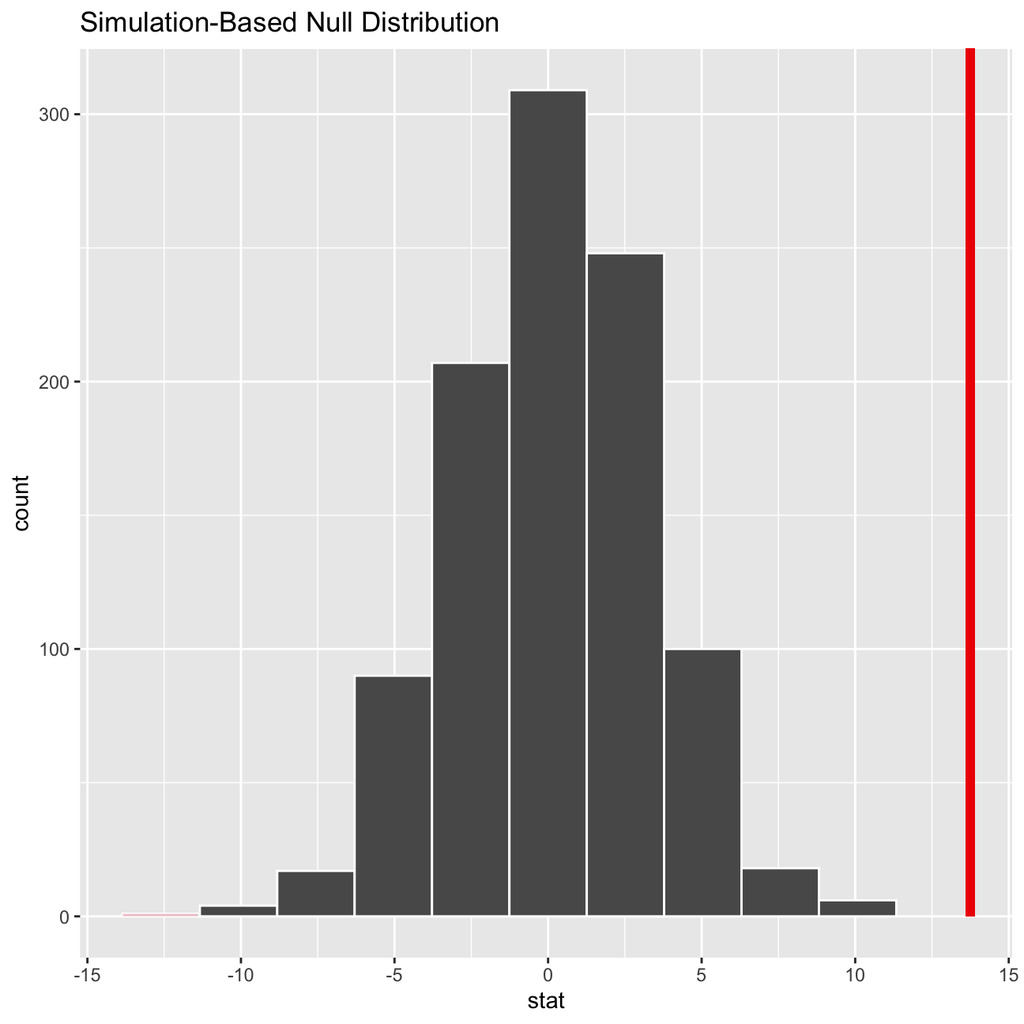

```r
  visualize(null_distribution_exp, bins =10)+

  shade_p_value(obs_stat =obs_diff_means_exp, direction = "both")
```

```r
obs_diff_means %>%
  get_p_value(obs_stat = obs_diff_means_exp, direction = "both")
```

```
## # A tibble: 1 x 1
##   p_value
##     <dbl>
## 1       0
```

Conclusion:

Both methods show us that there is a statistically significant difference in experience between men and women

- summary statistics show that the confidence intervals do not overlap
- the t.test method shows a p value < 0.05, a t value whose absolute value is higher than 2, and the confidence interval does not include 0
- the infer method shows that the probability of an observed difference in means of about 14 years is very unlikely (p value = 0) when H0=there is no difference in experience between genders holds true

There is still a significant difference in female and male salaries, however, this additional analysis shows that this difference is partly caused by the higher years of experience of the male executives. Overall, it weakens the argument that the difference in pay is solely due to discrimination.

## Relationship Salary - Experience ?

Let’s have a closer look at the relationship between experience in salary using a scatter plot

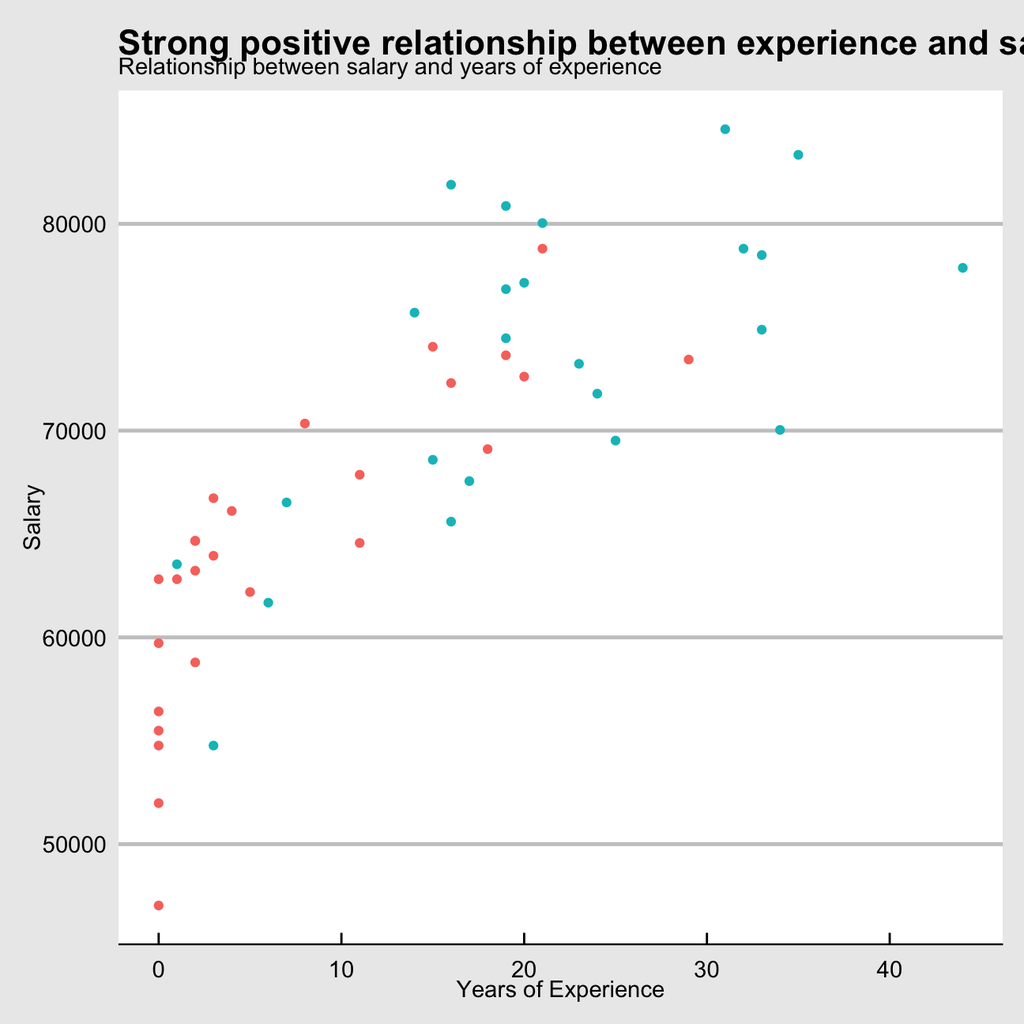

```r
# create plot from data omega where x axis shows experience, and y axis shows salary

ggplot(omega, aes(x = experience, y=salary,color=gender))+

# use geom_point to create a scatterplot

  geom_point()+

# add a theme and labels

  theme_economist_white()+

  labs(
    title = "Strong positive relationship between experience and salary",
    subtitle = "Relationship between salary and years of experience",
    x ="Years of Experience",
    y ="Salary")+

  # remove legend

  theme(legend.position = "none")+

  NULL
```